# Improving Data Representativeness/Fairness Via Interoperability

This notebook is intended to demonstrate how interoperating systems can help improve representativeness of subsets in a dataset (e.g., demographics, disease distribution).

To demonstrate this, we'll use a synthetic database that has also been used for other MIDRC tutorials. It can be downloaded at this link: [Data Download](https://urldefense.com/v3/__https://data.midrc.org/discovery/P67C-YW55/__;!!BpyFHLRN4TMTrA!666m00AqV8nfseAVd-km2XR10q_gp0aZooBsKRmEJ9HRCjC4UCxHIglBJ3Q9vwvC76Yhp1DJEkgqYmBOQNyad_ws_A$). Note, you must be signed in to the MIDRC Data Commons at data.midrc.org to access the file, the download button can be found at the bottom of the opened tab. When you download the file, please save it in your current working directory for this notebook.

Now, we will begin the tutorial by loading packages and defining useful functions that will be used to create plots for visualizing representation later. Run the next two cells of code.

```python
import pandas as pd
import urllib.request
import sys
import matplotlib.pyplot as plt
import numpy as np

from pathlib import Path
```

```python
np.random.seed(4)

def radar_plot(jsd_dicts, labels, features, title=None, rmax=1.0):
    """
    Create radar/spider charts to visualize JSD comparison of data subsets

    jsd_dicts: list[dict] each dict maps feature->value
    labels:    list[str] legend labels for each dict
    features:  list[str] axis labels in desired order
    """
    N = len(features)
    angles = np.linspace(0, 2*np.pi, N, endpoint=False).tolist()
    angles += angles[:1]

    fig = plt.figure(figsize=(8, 8))
    ax = plt.subplot(111, polar=True)

    for d, lab in zip(jsd_dicts, labels):
        values = [float(d.get(f, np.nan)) for f in features]
        values += values[:1]
        ax.plot(angles, values, linewidth=2, label=lab)
        ax.fill(angles, values, alpha=0.15)

    ax.set_xticks(angles[:-1])
    ax.set_xticklabels(features)
    ax.set_ylim(0, rmax)
    ax.grid(True)

    if title:
        ax.set_title(title, y=1.08)

    ax.legend(loc="upper right", bbox_to_anchor=(1.35, 1.10), frameon=False)
    plt.tight_layout()
    return fig, ax


def pie_chart_plots(df, columns):
    '''
    Visualize pie charts for specified dataframe columns

    df: pandas dataframe
    columns: dataframe variables to be plotted

    output: len(columns) pie charts
    '''
    n_rows = len(columns)
    fig, axes = plt.subplots(nrows=n_rows, ncols=1, figsize=(12, 4 * n_rows))
    fig.subplots_adjust(right=0.82, hspace=0.7)

    cmap = plt.get_cmap("tab20")

    for i, c in enumerate(columns):
        ax = axes[i]

        counts = df[c].value_counts(dropna=True).sort_values(ascending=False)
        total = counts.sum()
        pct = (counts / total * 100) if total > 0 else (counts * 0)

        labels = counts.index.tolist()
        values = counts.values

        colors = [cmap(k % cmap.N) for k in range(len(values))]

        wedges, _ = ax.pie(
            values,
            labels=None,
            startangle=90,
            colors=colors,
            radius=1.15
        )
        ax.set_title(f"{c}\nALL", pad=10)

        legend_labels = [f"{lab} ({p:.1f}%)" for lab, p in zip(labels, pct.values)]

        ax.legend(
            wedges, legend_labels,
            loc="center left",
            bbox_to_anchor=(1.02, 0.5),
            borderaxespad=0.0,
            frameon=False,
            fontsize=9
        )

def pie_chart_plots2(columns, groups):
    '''
    Creates pie charts to visualize data distributions.

    columns: list of dataframe columns to be visualized
    groups: list of tuples, each tuple is 2 elements formatted (<group name, string>, dataframe)
            each tuple defines a set of pie charts to be created

    output: len(groups) columns of pie charts, each column containing len(columns) rows
    '''
    n_rows = len(columns)
    n_cols = len(groups)

    fig, axes = plt.subplots(nrows=n_rows, ncols=n_cols, figsize=(18, 4 * n_rows))
    axes = np.atleast_2d(axes)

    plt.subplots_adjust(wspace=0.9, hspace=0.8)

    cmap = plt.get_cmap("tab20")

    for i, c in enumerate(columns):
        for j, (title, df_sub) in enumerate(groups):
            ax = axes[i, j]

            counts = df_sub[c].value_counts(dropna=True).sort_values(ascending=False)

            total = counts.sum()
            pct = (counts / total * 100) if total > 0 else (counts * 0)

            labels = counts.index.tolist()
            values = counts.values

            colors = [cmap(k % cmap.N) for k in range(len(values))]

            wedges, _ = ax.pie(
                values,
                labels=None,
                startangle=90,
                colors=colors
            )
            ax.set_title(f"{c}\n{title}")

            legend_labels = [f"{lab} ({p:.1f}%)" for lab, p in zip(labels, pct.values)]

            ax.legend(
                wedges, legend_labels,
                loc="upper center",
                bbox_to_anchor=(0.5, -0.10),
                ncol=1,
                frameon=False,
                fontsize=9
            )
```

We will also need to access some functions that are used in other MIDRC tools, namely the MIDRC Generalized Stratified Sampling and REACT tools. This next cell will create a new directory called "utilities" in your current working directory, retrieve the files we need from the public GitHub repositories for those tools, and save them in that directory. You can see at the end of the cell that these functions are for calculating the Jenson-Shannon distance (JSD) between two sets of data and for performing stratified sampling.

```python
url = "https://raw.githubusercontent.com/MIDRC/Generalized_Stratified_Sampling/refs/heads/main"

#Create needed directories
utils_dir = Path("utilities")
utils_dir.mkdir(exist_ok=True)
core_dir = utils_dir / "midrc_react" / "core"
core_dir.mkdir(parents=True, exist_ok=True)

#Get Stratified Sampling files
files = ["stratified_sampling.py", "CONFIG.py", "data_preprocessing.py"]
for f in files:
    urllib.request.urlretrieve(f"{url}/{f}", utils_dir / f)
sys.path.insert(0, str(utils_dir))

#Get MIDRC-REACT files
core_dir = utils_dir / "midrc_react" / "core"
core_dir.mkdir(parents=True, exist_ok=True)

url = "https://raw.githubusercontent.com/MIDRC/MIDRC-REACT/refs/heads/master/src/midrc_react/core/"
files = ["aggregate_jsd_calc.py", "data_preprocessing.py"]

for f in files:
    urllib.request.urlretrieve(f"{url}/{f}", core_dir / f)

sys.path.insert(0, str(utils_dir))

from midrc_react.core.aggregate_jsd_calc import calc_jsd_by_features_2df, calc_jsd_by_features
from CONFIG import SamplingData
from stratified_sampling import stratified_sampling
```

Now that we have all the functions and packages we'll need, we can start working with the data. Ensure that the downloaded dataset is saved in the current working directory (or modify the file path in the "read_excel" function below to the correct path).

The data needs to be preprocessed in a way that allows for better visualization and for stratification; specifically, numeric variables must be binned into distinct categories. In our dataset, age is the only continuous numeric variable so we provide ~10-year age bins starting at adulthood (age 18). Additionally, our dataset has information about imaging for each patient in the "modality" column indicating if the patient has CR, DX, CT, and MRI data available. In this example, we will suppose that we are only interested in if the patient has either DX or CT images and provide an additional column in a more functional format called "modality_categorized" that indicates more specifically for these 2 imaging modalities.

```python
all_data = pd.read_excel('MIDRC_Stratified_Sampling_Example_5000_Patient_Subset.xlsx')
all_data = all_data.drop(columns=['dataset', 'batch'])
all_data = all_data.rename(columns={"covid19_positive":"disease_status"})

age_groups = [0, 17, 29, 39, 49, 59, 69, 79, 100]
age_labels = ['0-17', '18-29', '30-39', '40-49', '50-59', '60-69', '70-79', '80+']
all_data['age_group'] = pd.cut(all_data['age_at_index'], bins=age_groups, labels=age_labels)

s1 = "CT"
s2 = "DX"
m1 = all_data["modality"].fillna("").str.contains(s1, case=False, na=False)
m2 = all_data["modality"].fillna("").str.contains(s2, case=False, na=False)

all_data["modality_categorized"] = np.select([~m1&~m2, m1&~m2, ~m1&m2, m1&m2], ["neither", f"only_{s1}", f"only_{s2}", "both"], default="neither")


print(all_data.head())
```

```
  submitter_id  age_at_index disease_status               ethnicity  \
0    case_0001            27            Yes  Not Hispanic or Latino
1    case_0002            84            Yes  Not Hispanic or Latino
2    case_0003            65            Yes  Not Hispanic or Latino
3    case_0004            69            Yes  Not Hispanic or Latino
4    case_0005            37            Yes  Not Hispanic or Latino

                        race     sex modality age_group modality_categorized
0  Black or African American  Female       CR     18-29              neither
1                      White    Male       DX       80+              only_DX
2                      White    Male       CR     60-69              neither
3                      White    Male       DX     60-69              only_DX
4  Black or African American    Male       DX     30-39              only_DX
```

First, let's take a look at the distributions of different variables in our subset using the pie chart function we defined before, noting the overall distribution of each variable.

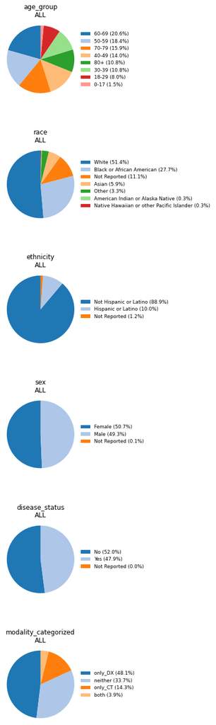

```python
columns = ['age_group', 'race', 'ethnicity', 'sex', 'disease_status', 'modality_categorized']

pie_chart_plots(all_data, columns)
plt.show()
```

The goal of this tutorial is to evaluate how interoperating datasets can improve representativeness, so we need to simulate interoperating datasets. Thus, we divide our database into 2 subsets, one with demographic features and one with disease and imaging data, simulating 2 interoperating sites. We'll call these df_site1 (holding variables related to demographics, Site 1) and df_site2 (holding the disease and imaging data variables, Site 2).

```python
df_site1 = all_data[["submitter_id", "age_at_index", "ethnicity", "race", "sex", "age_group"]]
df_site2 = all_data[["submitter_id", "disease_status", "modality_categorized"]]
```

Let's focus on just the demographic data site (Site 1) to begin. Suppose we are interested in developing a database into training and testing subsets for training a machine learning algorithm. One way to split data is through stratified sampling, where the distribution of selected variables is matched across data partitions. MIDRC has developed a general stratified sampling algorithm and tool to perform such data splitting; we've already pulled some functions from the associated GitHub repository, so we'll utilize those to split the data from Site 1 into training and testing subsets of 80% and 20%, respectively.

```python
sampling_data = SamplingData(
    filename=None,
    dataset_column="dataset",
    features=["age_at_index", "ethnicity", "race", "sex"],
    title="Site 1 Stratified Sampling",
    datasets={"Training":0.8, "Testing":0.2},
    numeric_cols={'age_at_index':{'bins':[0, 18, 30, 40, 50, 60, 70, 80, 1000], 'labels':['0-17','18-29','30-39','40-49','50-59','60-69','70-79','80+']}},
    uid_col="submitter_id")

df_site1_strat = stratified_sampling(df_site1, sampling_data)

print(df_site1_strat.head())
```

```
  submitter_id  age_at_index               ethnicity  \
0    case_0001            27  Not Hispanic or Latino
1    case_0002            84  Not Hispanic or Latino
2    case_0003            65  Not Hispanic or Latino
3    case_0004            69  Not Hispanic or Latino
4    case_0005            37  Not Hispanic or Latino

                        race     sex age_group   dataset
0  Black or African American  Female     18-29  Training
1                      White    Male       80+  Training
2                      White    Male     60-69  Training
3                      White    Male     60-69  Training
4  Black or African American    Male     30-39  Training
```

Now let's plot the demographic variable distributions for the training subset, testing subset, and full dataset so that we can compare distributions.

[output not shown]

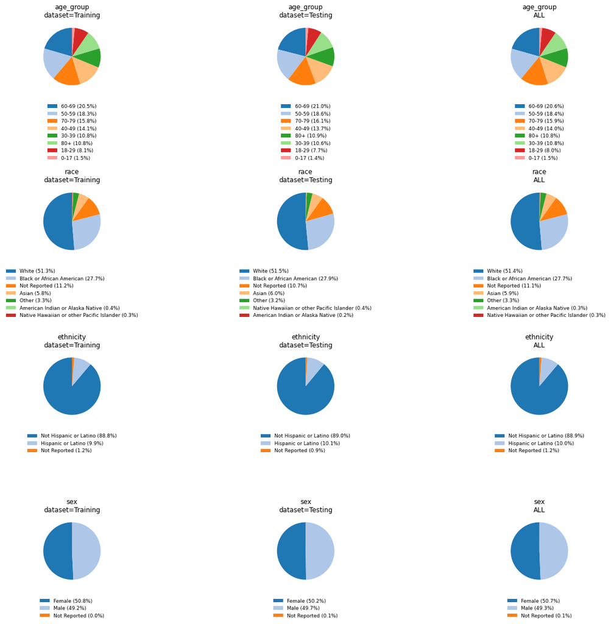

```python
columns = ['age_group', 'race', 'ethnicity', 'sex']
split_col = "dataset"
v1, v2 = "Training", "Testing"

groups = [
    (f"{split_col}={v1}", df_site1_strat[df_site1_strat[split_col] == v1]),
    (f"{split_col}={v2}", df_site1_strat[df_site1_strat[split_col] == v2]),
    ("ALL", df_site1_strat)
]

pie_chart_plots2(columns, groups)
print(groups)

plt.tight_layout()
plt.show()
```

Note that, for the most part, the training and validation subsets are very similar to each other and to the overall dataset. However, let's look at the distributions of the non-demographic variables (Site 2) that we achieved by sampling over our demographic (Site 1 variables).

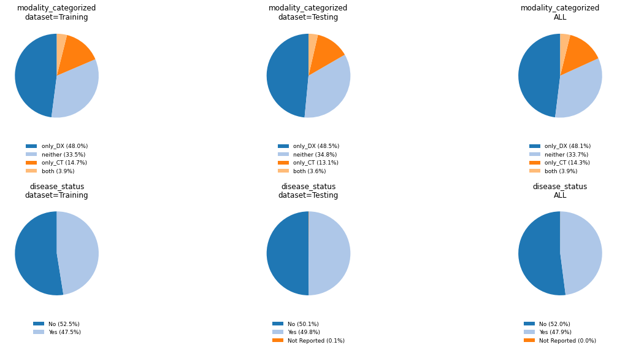

```python
df_site2_s1strat = df_site2.copy()
df_site2_s1strat["dataset"] = df_site1_strat["dataset"].values

columns = ["modality_categorized", "disease_status"]
split_col = "dataset"
v1, v2 = "Training", "Testing"

groups = [
    (f"{split_col}={v1}", df_site2_s1strat[df_site2_s1strat[split_col] == v1]),
    (f"{split_col}={v2}", df_site2_s1strat[df_site2_s1strat[split_col] == v2]),
    ("ALL", df_site2_s1strat),
]

pie_chart_plots2(columns, groups)

plt.tight_layout()
plt.show()
```

Notably, the non-demographic (Site 2) variables do not achieve the same similarity as the demographic variables (Site 1) because they were not considered in the data stratification. It is important to note that, by chance, these variables are not neccessarily matched worse than the demographic variables, but that we increase the likelihood of this happening by not including them in the stratification.

We can quantify the similarity between subsets via the Jenson-Shannon Distance (JSD). Smaller JSD values indicate better matching across different subsets. In this tutorial, the JSD values that we will show compare the Training and Testing subsets, ignoring the comparison to the overall dataset.

```
JSD for feature age_group:0.010511574286073177
JSD for feature race:0.018233603104896908
JSD for feature ethnicity:0.013489099999595546
JSD for feature sex:0.00916418745943001
JSD for feature modality_categorized:0.022187360048203108
JSD for feature disease_status:0.03013432770823218
```

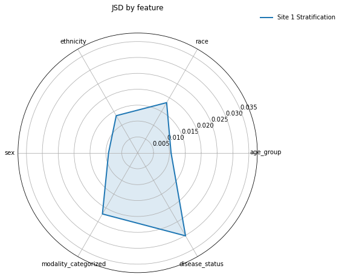

```python
columns = ["age_group", "race", "ethnicity", "sex", "modality_categorized", "disease_status"]
df_site1_strat["modality_categorized"] = df_site2["modality_categorized"].values
df_site1_strat["disease_status"] = df_site2["disease_status"].values

jsd1 = {}
for c in columns:
    jsd1[c] = calc_jsd_by_features_2df(df_site1_strat[df_site1_strat["dataset"]=="Training"], df_site1_strat[df_site1_strat["dataset"]=="Testing"], cols_to_use=[c])
    print(f"JSD for feature {c}:{jsd1[c]}")

radar_plot(jsd_dicts=[jsd1], labels=["Site 1 Stratification"], features=columns, title="JSD by feature", rmax=max(jsd1.values())*1.25)
plt.show()
```

As expected, we see larger JSD values for the non-demographic variables (modality_categorized, disease_status) compared to the demographic variables.

Now, we will repeat this process but swap the Site 1 and Site 2 data (i.e., perform stratified sampling on the site 2 variables this time).

```python
sampling_data = SamplingData(
    filename=None,
    dataset_column="dataset",
    features=["modality_categorized", "disease_status"],
    title="Site 2 Stratified Sampling",
    datasets={"Training":0.8, "Testing":0.2},
    numeric_cols={},
    uid_col="submitter_id")

df_site2_strat = stratified_sampling(df_site2, sampling_data)

print(df_site2_strat.head())
```

```
  submitter_id disease_status modality_categorized   dataset
0    case_0001            Yes              neither  Training
1    case_0002            Yes              only_DX   Testing
2    case_0003            Yes              neither  Training
3    case_0004            Yes              only_DX  Training
4    case_0005            Yes              only_DX  Training
```

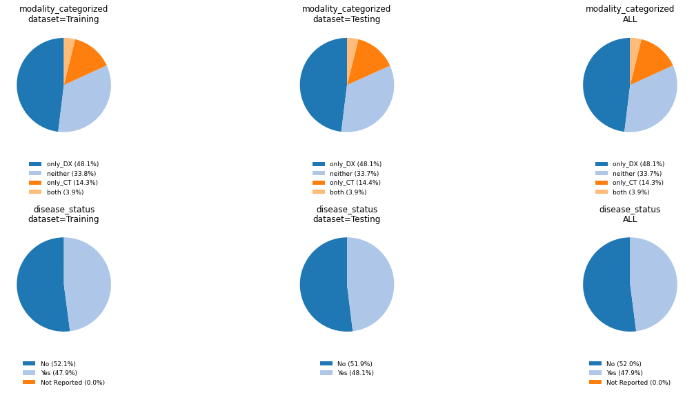

```python
columns = ["modality_categorized", "disease_status"]
split_col = "dataset"
v1, v2 = "Training", "Testing"

groups = [
    (f"{split_col}={v1}", df_site2_strat[df_site2_strat[split_col] == v1]),
    (f"{split_col}={v2}", df_site2_strat[df_site2_strat[split_col] == v2]),
    ("ALL", df_site2_strat),
]

pie_chart_plots2(columns, groups)

plt.tight_layout()
plt.show()
```

Qualitatively, it seems from the pie charts here compared to the pie charts from when we used demographic variables for stratification that the Site 2 variables are now better matched across subsets. This is as expected. We'll now show the opposite effect for the Site 1 variables.

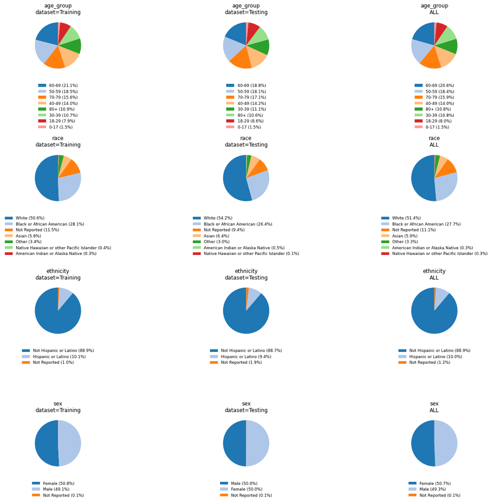

```python
df_site1_s2strat = df_site1.copy()
df_site1_s2strat["dataset"] = df_site2_strat["dataset"].values

columns = ["age_group", "race", "ethnicity", "sex"]
split_col = "dataset"
v1, v2 = "Training", "Testing"

groups = [
    (f"{split_col}={v1}", df_site1_s2strat[df_site1_s2strat[split_col] == v1]),
    (f"{split_col}={v2}", df_site1_s2strat[df_site1_s2strat[split_col] == v2]),
    ("ALL", df_site1_s2strat),
]

pie_chart_plots2(columns, groups)

plt.tight_layout()
plt.show()
```

It may be difficult to evaluate all of these qualitatively, but what we should see are larger differences between the demographic varibale distributions across subsets than we saw before. This tends to be more evident when there are more variable possibilities present (e.g., in the age_group and race variables in this category). We'll once again utilize the JSD to quantify distribution similarity.

```
JSD for feature age_group:0.03063708975700618
JSD for feature race:0.04831477567493617
JSD for feature ethnicity:0.03448631154034046
JSD for feature sex:0.010713813753663474
JSD for feature modality_categorized:0.0013471689678381568
JSD for feature disease_status:0.01123503018755874
```

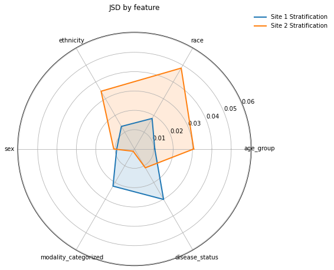

```python
columns = ["age_group", "race", "ethnicity", "sex", "modality_categorized", "disease_status"]
df_site2_strat["age_group"] = df_site1["age_group"].values
df_site2_strat["race"] = df_site1["race"].values
df_site2_strat["ethnicity"] = df_site1["ethnicity"].values
df_site2_strat["sex"] = df_site1["sex"].values

jsd2 = {}
for c in columns:
    jsd2[c] = calc_jsd_by_features_2df(df_site2_strat[df_site2_strat["dataset"]=="Training"], df_site2_strat[df_site2_strat["dataset"]=="Testing"], cols_to_use=[c])
    print(f"JSD for feature {c}:{jsd2[c]}")

radar_plot(jsd_dicts=[jsd1, jsd2], labels=["Site 1 Stratification", "Site 2 Stratification"], features=columns, title="JSD by feature", rmax=max(max(jsd1.values()),max(jsd2.values()))*1.25)
plt.show()
```

Finally, we will show how stratified over both site's variables combined improves representativeness in the training/testing split.

```python
sampling_data = SamplingData(
    filename=None,
    dataset_column="dataset",
    features=["age_group", "race", "ethnicity", "sex", "modality_categorized", "disease_status"],
    title="All Data Stratified Sampling",
    datasets={"Training":0.8, "Testing":0.2},
    numeric_cols={},
    uid_col="submitter_id")

df_all_strat = stratified_sampling(all_data, sampling_data)

print(df_all_strat.head())
```

```
  submitter_id  age_at_index disease_status               ethnicity  \
0    case_0001            27            Yes  Not Hispanic or Latino
1    case_0002            84            Yes  Not Hispanic or Latino
2    case_0003            65            Yes  Not Hispanic or Latino
3    case_0004            69            Yes  Not Hispanic or Latino
4    case_0005            37            Yes  Not Hispanic or Latino

                        race     sex modality age_group modality_categorized  \
0  Black or African American  Female       CR     18-29              neither
1                      White    Male       DX       80+              only_DX
2                      White    Male       CR     60-69              neither
3                      White    Male       DX     60-69              only_DX
4  Black or African American    Male       DX     30-39              only_DX

    dataset
0  Training
1  Training
2   Testing
3  Training
4  Training
```

As before, we visualize the variable distributions for both Site 1 and Site 2.

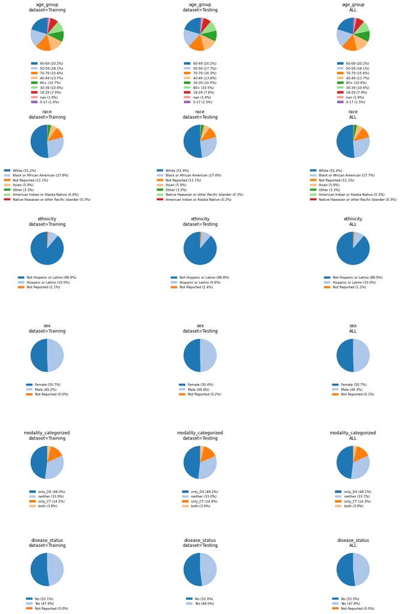

```python
columns = ["age_group", "race", "ethnicity", "sex", "modality_categorized", "disease_status"]
split_col = "dataset"
v1, v2 = "Training", "Testing"

groups = [
    (f"{split_col}={v1}", df_all_strat[df_all_strat[split_col] == v1]),
    (f"{split_col}={v2}", df_all_strat[df_all_strat[split_col] == v2]),
    ("ALL", df_all_strat),
]

pie_chart_plots2(columns, groups)

plt.tight_layout()
plt.show()
```

And finally, we quantify the comparison with the JSD.

```
JSD for feature age_group:0.012779933563241419
JSD for feature race:0.014999511283776247
JSD for feature ethnicity:0.012365893326651741
JSD for feature sex:0.02391632106617098
JSD for feature modality_categorized:0.009426707375618812
JSD for feature disease_status:0.01120882649402947
```

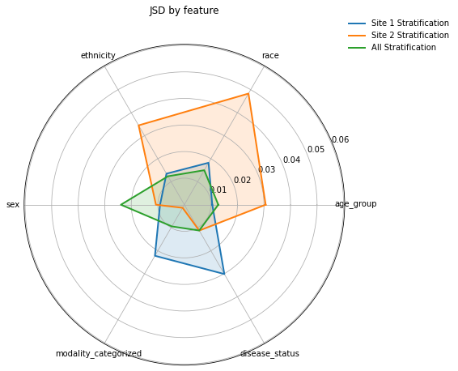

```python
columns = ["age_group", "race", "ethnicity", "sex", "modality_categorized", "disease_status"]

jsd3 = {}
for c in columns:
    jsd3[c] = calc_jsd_by_features_2df(df_all_strat[df_all_strat["dataset"]=="Training"], df_all_strat[df_all_strat["dataset"]=="Testing"], cols_to_use=[c])
    print(f"JSD for feature {c}:{jsd3[c]}")

radar_plot(jsd_dicts=[jsd1, jsd2, jsd3], labels=["Site 1 Stratification", "Site 2 Stratification", "All Stratification"], features=columns, title="JSD by feature", rmax=max(max(jsd1.values()),max(jsd2.values()), max(jsd3.values()))*1.25)
plt.show()
```

As expected, stratifying across both sites combined achieved better average JSD values than stratifying across either of the Site 1 or Site 2 variables alone. This emphasizes that when we have more information available from multiple sites, we are able to improve the representation of different variables in our training and testing subsets; this allows for more appropriate model development and evaluation as certain populations are not unfairly weighted due to overrepresentation or underrepresentation.

This concludes the tutorial.